# Explore Overlap between Test Chemicals Screened with HTTr and RefChemDB Annotations

Joseph Bundy

3/14/2025

## Background

There are over 1.7k chemicals screened in the large MCF-7 HTTr screen, but many of these are not associated with a known molecular target. This notebook explores the overlap in chemical target annotations in RefChemDB in the context of what chemicals were included in the HTTr screen.

## Data Analysis

Import raw refchemdb file and survey the number of chemicals and targets contained therein

```r
require(readxl)
target_annotations <- data.frame(read_excel("../data/refchemdb/NIHMS1537541-supplement-Supplement1.xlsx",
                                            sheet = "S12 Data"))

message("RefChemDB contains ", nrow(target_annotations), " entries spanning ", length(unique(target_annotations$dsstox_substance_id)), " chemicals and ", length(unique(target_annotations$target)), " targets")
```

```
RefChemDB contains 339008 entries spanning 31121 chemicals and 6433 targets
```

Import MIEML functions and pre-process RefChemDB annotations

```r
#load mieml_httrpl functions
source("../scripts/ML_functions_HTTr.R")

collapsed_refchemdb_targets <- collapse_refchemdb_targets(refchemdb_path = "../data/refchemdb/NIHMS1537541-supplement-Supplement1.xlsx",
                                                          support_levels = c(3),
                                                          min_chemicals = 5,
                                                          cutree_h = 0.7,
                                                          cluster_method= "complete")
```

```
This will probably take some time...
importing refchem
tabulating targets
calculating jaccard indices
editing chemical manifest
```

Pull out the refchem_collapsed object as processed refchemdb annotations to be used in downstream functions.

```r
refchem_collapsed <- collapsed_refchemdb_targets$collapsed_targets
refchem_collapsed <- refchem_collapsed[refchem_collapsed$support >= 3,]
```

Ensure that each chemical is matched to only one target in RefChemDB

```r
    stingy_target_annotations <- data.frame()
    for (i in unique(refchem_collapsed$dsstox_substance_id)){
      relevant_targets <- refchem_collapsed[refchem_collapsed$dsstox_substance_id == i,]
      if(nrow(relevant_targets) > 0){
        relevant_targets <- relevant_targets[order(relevant_targets$support, decreasing = TRUE),]
        stingy_target_annotations <- rbind(head(relevant_targets, 1), stingy_target_annotations)
      }
    }
    refchem_collapsed <- stingy_target_annotations
    rm(stingy_target_annotations)
```

Tabulate the number of chemicals available for each target_mode with table_targets()

```r
target_table <- table_targets(refchem_collapsed)
head(target_table)
```

|  | target_mode | members |
| --- | --- | --- |
| 68 | CA2_Negative_group | 102 |
| 13 | PTGS2_Negative_group | 45 |
| 19 | PPARG_Positive_group | 35 |
| 263 | ESR1_Positive_group | 33 |
| 78 | ACHE_Negative_group | 32 |
| 216 | KCNH2_Negative | 31 |

filter target table down to only targets that are associated with at least 5 chemical treatments

```r
target_table_filtered <- target_table[target_table$members >= 5,]
```

import well information for mcf7 screen

```r
metadata <- readRDS("../data/mongodb_dump/httr_metadata.rds")

#remove data from DMSO wells as well as water samples
metadata <- metadata[metadata$stype == "test sample",]
metadata <- metadata[!grepl("Water", metadata$chem_name),]
```

Inspect the HTTr metadata object

```r
head(metadata)
```

|  | chem_id | sample_id | plate_id | well_id | trt_name | qc_flag | stype | media | timeh | rna_src | conc | conc_unit | dose_level | block_id | pg_id | culture_id | n_reads | qc_id | n_reads_mapd | mapd_frac | bad_probe_count | n_cov5 | n_sig80 | top10_prop | gini_coef | chem_name | dtxsid |
| --- | --- | --- | --- | --- | --- | --- | --- | --- | --- | --- | --- | --- | --- | --- | --- | --- | --- | --- | --- | --- | --- | --- | --- | --- | --- | --- | --- |
| 921 | EPAPLT0027A01 | TC00503973_O05 | TC00503973 | O05 | EPAPLT0027A01_6_9.433962uM | OK | test sample | DMEM | 6 | Plated Cells | 9.4339623 | uM | 6 | 3 | 39 | c2017-10-26 | 6816416 | 5e17c4004bac743bbb7ae309 | 6321230 | 0.9273539 | 79366 | 11137 | 1987 | 0.03015900 | 0.8843873 | Aldicarb sulfoxide | DTXSID1033161 |
| 922 | EPAPLT0027A01 | TC00504005_G22 | TC00504005 | G22 | EPAPLT0027A01_3_0.299461uM | OK | test sample | DMEM | 6 | Plated Cells | 0.2994610 | uM | 3 | 3 | 39 | c2017-10-27 | 4515045 | 5e17c8574bac743bbb7af9ff | 3849391 | 0.8525698 | 37333 | 10517 | 1958 | 0.02792909 | 0.8852139 | Aldicarb sulfoxide | DTXSID1033161 |
| 923 | EPAPLT0027A01 | TC00503941_B07 | TC00503941 | B07 | EPAPLT0027A01_4_0.994036uM | OK | test sample | DMEM | 6 | Plated Cells | 0.9940358 | uM | 4 | 3 | 39 | c2017-10-25 | 2909241 | 5e17bf4f4bac743bbb7aca38 | 2582317 | 0.8876257 | 23222 | 9850 | 1966 | 0.02929346 | 0.8848988 | Aldicarb sulfoxide | DTXSID1033161 |
| 924 | EPAPLT0027A01 | TC00503973_H07 | TC00503973 | H07 | EPAPLT0027A01_1_0.029935uM | OK | test sample | DMEM | 6 | Plated Cells | 0.0299347 | uM | 1 | 3 | 39 | c2017-10-26 | 3750034 | 5e17c3e14bac743bbb7ae268 | 3490054 | 0.9306726 | 41414 | 10556 | 2157 | 0.02554688 | 0.8760548 | Aldicarb sulfoxide | DTXSID1033161 |
| 925 | EPAPLT0027A01 | TC00503941_J03 | TC00503941 | J03 | EPAPLT0027A01_2_0.099940uM | OK | test sample | DMEM | 6 | Plated Cells | 0.0999400 | uM | 2 | 3 | 39 | c2017-10-25 | 2687962 | 5e17bf724bac743bbb7acaf4 | 2404081 | 0.8943880 | 27713 | 9488 | 1843 | 0.03146608 | 0.8913527 | Aldicarb sulfoxide | DTXSID1033161 |
| 926 | EPAPLT0027A01 | TC00504005_J11 | TC00504005 | J11 | EPAPLT0027A01_4_0.994036uM | OK | test sample | DMEM | 6 | Plated Cells | 0.9940358 | uM | 4 | 3 | 39 | c2017-10-27 | 3214787 | 5e17c8634bac743bbb7afa3c | 2919578 | 0.9081715 | 32801 | 10054 | 1988 | 0.02849453 | 0.8841821 | Aldicarb sulfoxide | DTXSID1033161 |

How many chemicals and gene expression profiles are covered in this object?

```r
message(length(unique(metadata$dtxsid)), " unique chemical treatments")
```

```
1750 unique chemical treatments
```

```r
message(nrow(metadata), " profiles")
```

```
42445 profiles
```

Define function for manually controlling ggplot2 colors

```r
gg_color_hue <- function(n) {
  hues = seq(15, 375, length = n + 1)
  hcl(h = hues, l = 65, c = 100)[1:n]
}
```

Generate a histogram showing how many screened chemicals were linked to RefChemDB targets

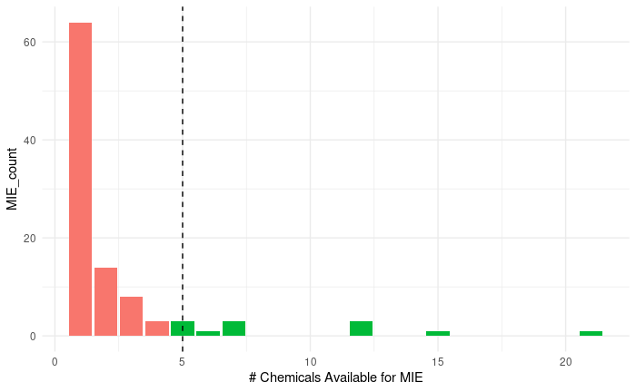

```r
library(ggplot2)
library(data.table)

plot_list <- list()

temp_target_table <- refchem_collapsed[refchem_collapsed$dsstox_substance_id %in% metadata$dtxsid,]
temp_target_table <- unique(temp_target_table[,c("dsstox_substance_id", "support", "target_mode")])
temp_target_table <- data.frame(table(temp_target_table$target_mode))
temp_target_table <- data.table(temp_target_table)
temp_target_table <- temp_target_table[,.(MIE_count=length(unique(Var1))),by=Freq]
temp_target_table$fill <- "holder"
temp_target_table[temp_target_table$Freq < 5,]$fill <- "insufficient data"
temp_target_table[temp_target_table$Freq >= 5,]$fill <- "sufficient data"

plot_list[["MIE_coverage_barplot"]] <- ggplot(temp_target_table, aes(x = Freq, y = MIE_count, fill = fill)) +
geom_bar(stat = "identity") +
scale_fill_manual(values = gg_color_hue(3)[c(1,2)]) +
geom_vline(xintercept = 5, linetype = "dashed") +
theme_minimal() +
theme(legend.position = "none") +
xlab("# Chemicals Available for MIE")

plot_list[["MIE_coverage_barplot"]]
```

Not all gene expression profiles in this data set will be suitable for training data sets, as some of the profiles will correspond to concentrations where the chemical is not active. Identify the subset of profiles that are suitable for training.

```r
#import tPOD estimates
tpod_estimates <- read.csv("../data/tpod_estimates/tpod_estimates.csv", header = TRUE)

#merge tPOD estimates with metadata
bioactive_training_data <- merge(metadata, tpod_estimates[c("chem_id", "gene_bpac05")], by = "chem_id")

#retain only metadata where the treatment was a higher concentration than the tpod
bioactive_training_data <- bioactive_training_data[bioactive_training_data$conc > bioactive_training_data$gene_bpac05,]

#retain only the chemicals linked to RefChemDB targets
bioactive_training_data <- bioactive_training_data[bioactive_training_data$dtxsid %in% refchem_collapsed$dsstox_substance_id,]
```

After selecting the bioactive gene expression profiles, how many persist in training data?

```r
message(length(unique(bioactive_training_data$chem_id)), " unique chemical samples")
```

```
244 unique chemical samples
```

```r
message(length(unique(bioactive_training_data$dtxsid)), " unique chemicals")
```

```
237 unique chemicals
```

```r
message(nrow(bioactive_training_data), " profiles")
```

```
2265 profiles
```

Import and preprocess httrpl processed gene expression profiles

profile_size is an upper limit to the number of gene expression profiles that can be included in training data for any one chemical. If a chemical has more than profile_limit profiles, profiles will be dropped randomly so that there are profile_limit profiles per chemical.

```r
nested_data <- get_gene_expression_data(metadata = bioactive_training_data,
                                 seed = 123,
                                 gene_expression_data_path = "../data/gene_expression/normalized_gene_expression_data.rds",
                                profile_limit = 20)
```

```
- loading gene expression data -

Triming overrepresented chemicals from analysis
```

Tabulate gene expression profiles available for training MIE-specific models

Tabulate the number of available HTTr profiles for each target_mode, specifying minimum cutoffs for the number of chemicals and/or profiles required for the target_mode to be a viable target for prediction

```r
profile_table <- table_profiles(target_table = target_table,
                                 metadata =  nested_data$metadata,
                                 target_annotations = refchem_collapsed,
                                 exemplar_chems = NULL,
                                 min_profiles = 25,
                                 min_chemicals = 5)
profile_table
```

|  | target_mode | n_profiles | n_chemicals |
| --- | --- | --- | --- |
| 115 | ESR1_Positive_group | 213 | 21 |
| 100 | NR3C1_Positive | 135 | 7 |
| 118 | CA2_Negative_group | 113 | 14 |
| 85 | AHR_Positive | 111 | 6 |
| 97 | AR_Negative | 104 | 12 |
| 117 | PTGS2_Negative_group | 101 | 12 |
| 116 | PPARG_Positive_group | 98 | 12 |
| 114 | ACHE_Negative_group | 59 | 6 |
| 66 | NR1I2_Positive | 45 | 7 |

step through each chemical and assign a status based on presence in RefChemDB and whether there’s sufficient data to use that chem to train models

```r
httr_chem <- unique(metadata[c("chem_name","dtxsid")])

`%notin%` <- Negate(`%in%`)
httr_chem$use <- "holder"

for(temp_dtxsid in unique(httr_chem$dtxsid)){
  if (temp_dtxsid %in% refchem_collapsed$dsstox_substance_id){
  temp_target <- refchem_collapsed[refchem_collapsed$dsstox_substance_id == temp_dtxsid, "target_mode"]
  if (temp_target %in% profile_table$target_mode){
    httr_chem[httr_chem$dtxsid == temp_dtxsid,]$use <- "Linked to target"
  }
  if (temp_target %notin% profile_table$target_mode){
    httr_chem[httr_chem$dtxsid == temp_dtxsid,]$use <- "Linked to a target, insufficient data"
  }
  }
  if (temp_dtxsid %notin% refchem_collapsed$dsstox_substance_id){
    httr_chem[httr_chem$dtxsid == temp_dtxsid,]$use <- "Not linked to a target"
  }
}
```

```r
temp_httr_chem <- unique(httr_chem[c("dtxsid", "use")])
data.frame(table(httr_chem$use))
```

| Var1 | Freq |
| --- | --- |
| Linked to a target, insufficient data | 143 |
| Linked to target | 99 |
| Not linked to a target | 1508 |

Note, two chemicals are linked to targets that have sufficient data for modeling, but are absent in the metadata object that is used to construct training data sets. That is because these two chemicals have no concentration responsive genes, and so they are not actually used in classifier training.

```r
setdiff(temp_httr_chem[temp_httr_chem$use == "Linked to target",]$dtxsid, nested_data$metadata$dtxsid)
```

```
[1] "DTXSID6024177" "DTXSID1042574"
```

how many MIEs are represented in this data set that are not modeled due to insufficient data?

```r
length(unique(refchem_collapsed[refchem_collapsed$dsstox_substance_id %in% temp_httr_chem[temp_httr_chem$use == "Linked to a target, insufficient data",]$dtxsid,]$target_mode))
```

```
[1] 92
```

Generate pie graph showing proportion of chemicals linked to RefChemDB targets vs not

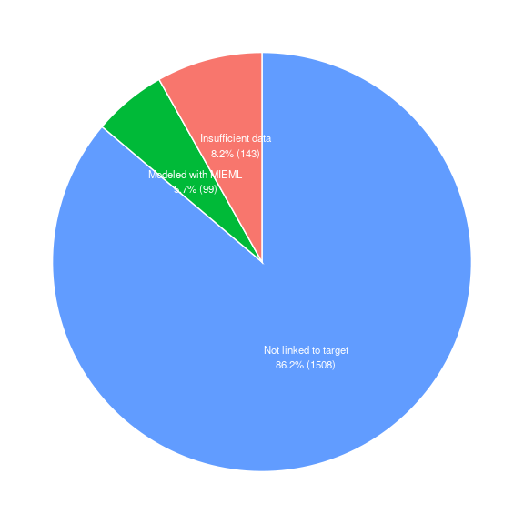

```r
library(dplyr)
library(plyr)
# Create Data
data <- data.frame(
  group=c("Modeled with MIEML\n5.7% (99)",
          "Not linked to target\n86.2% (1508)",
          "Insufficient data\n8.2% (143)\n\n"),
  value=c(99, 1508, 143)
)

#data <- data.table(data)

# Compute the position of labels
data <- data %>%
  arrange(desc(group)) %>%
  mutate(prop = value / sum(data$value) *100) %>%
  mutate(ypos = cumsum(prop)- 0.5*prop )

# Basic piechart
plot_list[["chemical_coverage_piegraph"]] <- ggplot(data, aes(x="", y=prop, fill=group)) +
#  ggtitle(label = paste0("HTTr and HTPP Bioactivity Concurrence for 1220 Test Chemicals")) +
  geom_bar(stat="identity", width=1, color="white") +
  coord_polar("y", start=0, direction = 1) +
  theme_void() +
  theme(legend.position="none") +

  geom_text(aes(y = ypos, label = group), color = "white", size=3) +
  #scale_fill_brewer(palette="Set2")
  scale_fill_manual(values = gg_color_hue(3)[c(1,2,3)])

plot_list[["chemical_coverage_piegraph"]]
```

Generate combination plot of histogram and pie graph

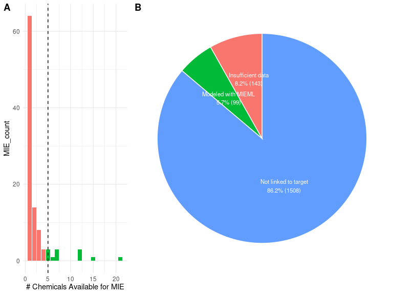

```r
library(cowplot)
plot_list[["combo_plot"]] <- plot_grid(plot_list[["MIE_coverage_barplot"]],
                                                 plot_list[["chemical_coverage_piegraph"]],
                                                 ncol = 2,
                                                 nrow = 1,
                                                 rel_widths = c(0.75,1.5),
                                                 align = "h",
                                                 axis = "tblr",
                                       labels = c("A", "B"))
plot_list[["combo_plot"]]
```

Save to disk

```r
tiff(filename = "../figures/refchemdb_coverage_combo.tiff", height = 6, width = 6, units = "in", res = 300)
plot_list[["combo_plot"]]
dev.off()
```

## Exemplar chemical identification

Using the previously generated refchemdb objects and HTTr data, identify a set of “exemplar” chemicals that are annotated for viable targets with a high support level. These chemicals and their profiles will be flagged for exclusion from training data in downstream analyses.

```r
exemplar_chems <- get_exemplar_chems(target_annotations = refchem_collapsed,
                                     metadata = nested_data$metadata,
                                     target_table = target_table,
                                     min_chemicals = 5,
                                     min_profiles = 25,
                                     profile_table = profile_table)

exemplar_chems
```

|  | dsstox_substance_id | casrn | name | target | target_type | mode | activity_class | support | in_cmap | target_mode |
| --- | --- | --- | --- | --- | --- | --- | --- | --- | --- | --- |
| 11 | DTXSID0020573 | 50-28-2 | 17beta-Estradiol | ESR1 | gene | Positive | active | 142 | 1 | ESR1_Positive_group |
| 37 | DTXSID8023688 | 97240-79-4 | Topiramate | CA2 | gene | Negative | active | 70 | 1 | CA2_Negative_group |
| 20 | DTXSID4020290 | 50892-23-4 | Pirinixic acid | PPARA | gene | Positive | active | 115 | 1 | PPARG_Positive_group |
| 19 | DTXSID0022777 | 169590-42-5 | Celecoxib | PTGS2 | gene | Negative | active | 120 | 1 | PTGS2_Negative_group |
| 179 | DTXSID7032004 | 13311-84-7 | Flutamide | AR | gene | Negative | active | 31 | 1 | AR_Negative |
| 888 | DTXSID6021244 | 13292-46-1 | Rifampicin | NR1I2 | gene | Positive | active | 12 | 1 | NR1I2_Positive |
| 56 | DTXSID3020384 | 50-02-2 | Dexamethasone | NR3C1 | gene | Positive | active | 56 | 1 | NR3C1_Positive |
| 22 | DTXSID1037272 | 321-64-2 | Tacrine | ACHE | gene | Negative | active | 110 | 1 | ACHE_Negative_group |
| 220 | DTXSID8030423 | 6051-87-2 | 5,6-Benzoflavone | AHR | gene | Positive | active | 29 | 0 | AHR_Positive |

After identifying exemplar chemicals, we need to re-run the table_HTTr_profiles function to revise estimates of how many profiles are available for training each MIE

```r
profile_table <- table_profiles(target_table = target_table,
                                metadata =  nested_data$metadata,
                                target_annotations = refchem_collapsed,
                                min_chemicals = 5,
                                min_profiles = 25,
                                exemplar_chems = exemplar_chems)
profile_table
```

|  | target_mode | n_profiles | n_chemicals |
| --- | --- | --- | --- |
| 115 | ESR1_Positive_group | 193 | 20 |
| 100 | NR3C1_Positive | 115 | 6 |
| 118 | CA2_Negative_group | 107 | 13 |
| 97 | AR_Negative | 98 | 11 |
| 85 | AHR_Positive | 93 | 5 |
| 117 | PTGS2_Negative_group | 89 | 11 |
| 116 | PPARG_Positive_group | 86 | 11 |
| 114 | ACHE_Negative_group | 53 | 5 |
| 66 | NR1I2_Positive | 33 | 6 |

generate a pretty graph showing this distribution

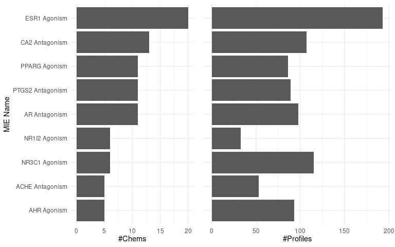

```r
library(cowplot)

#make MIE names more readable
temp <- profile_table

temp$target_mode <- make_annotations_pretty(temp$target_mode)

temp <- temp[order(temp$n_chemicals, decreasing = FALSE),]
temp$target_mode <- factor(temp$target_mode, levels = temp$target_mode)

names(temp) <- c("MIE Name", "#Profiles", "#Chems")

left_plot <- ggplot(temp, aes(x = `MIE Name`,y =  `#Chems`)) +
  geom_bar(stat = "identity") +
  theme_minimal() +
  coord_flip()

right_plot <- ggplot(temp, aes(x = `MIE Name`,y =  `#Profiles`)) +
  geom_bar(stat = "identity") +
  coord_flip() +
  theme_minimal() +
  theme(axis.text.y = element_blank(),
        axis.ticks.y =  element_blank(),
        axis.title.y = element_blank())

plot_grid(left_plot,
          right_plot,
          ncol = 2,
          nrow = 1,
          rel_widths = c(1,1),
          align = "h",
          axis = "tblr")
```

Save file to disk

```r
tiff(filename = "../figures/training_data_volume.tiff", height = 5, width = 8, units = "in", res = 300)
plot_grid(left_plot,
          right_plot,
          ncol = 2,
          nrow = 1,
          rel_widths = c(1,1),
          align = "h",
          axis = "tblr")
dev.off()
```